# parking_tickets

I will explore the April 2017 - March 2018 Parking Ticket data, available on MCCs open data site at https://www.manchester.gov.uk/open/downloads/download/109/parking_account. First we'll read it into a tibble (if you're unfamiliar, this is essentially a table) and remove two fields we don't want.

```r
library(readxl)
library(tibble)
parking_data <- read_excel("Parking_Account_17_18.xlsx")
parking_data <- as_tibble(parking_data)
parking_data$'Organisation name' <- NULL
parking_data$'Organisation Code' <- NULL
```

First let's see how dirty the data is, specifically the 'Ward' field:

```r
levels(as.factor(parking_data$Ward))
```

1. '(none)'

2. '(None)'

3. 'Anc&Clay'

4. 'Ardwick'

5. 'Baguley'

6. 'Barlow Moor'

7. 'Besw&Clayton'

8. 'Bradford'

9. 'Brooklands'

10. 'Burnage'

11. 'Central'

12. 'Charlestown'

13. 'Cheetham'

14. 'Chorlton'

15. 'ChorltonPark'

16. 'City Centre'

17. 'Crumpsall'

18. 'Didsbury'

19. 'Didsbury East'

20. 'Didsbury West'

21. 'Eastern Lap'

22. 'Fallowfield'

23. 'Gorton North'

24. 'Gorton South'

25. 'H4'

26. 'Harpurhey'

27. 'HighBlackley'

28. 'Hulme'

29. 'Hulme H4'

30. 'Levenshulme'

31. 'Longsight'

32. 'LOXFORDCOURT'

33. 'MISC'

34. 'Moss Side'

35. 'Moston'

36. 'MP&NH'

37. 'Newton Heath'

38. 'North Quarter'

39. 'Northenden'

40. 'Northernden'

41. 'Old Moat'

42. 'Rusholme'

43. 'Sharston'

44. 'Southern Lap'

45. 'WhalleyRange'

46. 'Withington'

47. 'WoodhsePark'

It certainly needs cleaning, but it could be a lot worse.

Let's clean up that Ward column. We make a new tibble, parking_test, to play with. Below we reassign the values we don't want.

NB The wards changed in May 2018 (since this data was collected) and I have tended to use the new ward names to make any analysis forward-compatible.

```r
parking_test <- parking_data
parking_test$Ward[parking_test$Ward=='Anc&Clay'] <- 'Ancoats & Beswick'
parking_test$Ward[parking_test$Ward=='WoodhsePark'] <- 'Woodhouse Park'
parking_test$Ward[parking_test$Ward=='WhalleyRange'] <- 'Whalley Range'
parking_test$Ward[parking_test$Ward=='Northernden'] <- 'Northenden'
parking_test$Ward[parking_test$Ward=='North Quarter'] <- 'City Centre'
parking_test$Ward[parking_test$Ward=='Newton Heath'] <- 'Miles Platting & Newton Heath'
parking_test$Ward[parking_test$Ward=='MP&NH'] <- 'Miles Platting & Newton Heath'
parking_test$Ward[parking_test$Ward=='MISC'] <- 'Unknown'
parking_test$Ward[parking_test$Ward=='ChorltonPark'] <- 'Chorlton Park'
parking_test$Ward[parking_test$Ward=='Central'] <- 'City Centre'
parking_test$Ward[parking_test$Ward=='Gorton North'] <- 'Gorton & Abbey Hey'
parking_test$Ward[parking_test$Ward=='Gorton South'] <- 'Gorton & Abbey Hey'
parking_test$Ward[parking_test$Ward=='Bradford'] <- 'Ancoats & Beswick'
parking_test$Ward[parking_test$Ward=='Besw&Clayton'] <- 'Clayton & Openshaw'
parking_test$Ward[parking_test$Ward=='HighBlackley'] <- 'Higher Blackley'
parking_test$Ward[parking_test$Ward=='H4'] <- 'Hulme'
parking_test$Ward[parking_test$Ward=='Hulme H4'] <- 'Hulme'
parking_test$Ward[parking_test$Ward=='Barlow Moor'] <- 'Chorlton Park'
parking_test$Ward[parking_test$Ward=='Didsbury'] <- 'Didsbury East'
parking_test$Ward[parking_test$Ward=='Eastern Lap'] <- 'City Centre'
parking_test$Ward[parking_test$Ward=='Southern Lap'] <- 'City Centre'
parking_test$Ward[parking_test$Ward=='LOXFORDCOURT'] <- 'Hulme'
parking_test$Ward[parking_test$Ward=='(none)'] <- 'Unknown'
parking_test$Ward[parking_test$Ward=='(None)'] <- 'Unknown'
parking_test$Ward[parking_test$Ward==NA] <- 'Unknown'
parking_test$Ward[parking_test$Ward==NULL] <- 'Unknown'
```

Now let's inspect our handiwork:

```r
parking_test$Ward <- as.factor(parking_test$Ward)
levels(parking_test$Ward)
```

1. 'Ancoats & Beswick'

2. 'Ardwick'

3. 'Baguley'

4. 'Brooklands'

5. 'Burnage'

6. 'Charlestown'

7. 'Cheetham'

8. 'Chorlton'

9. 'Chorlton Park'

10. 'City Centre'

11. 'Clayton & Openshaw'

12. 'Crumpsall'

13. 'Didsbury East'

14. 'Didsbury West'

15. 'Fallowfield'

16. 'Gorton & Abbey Hey'

17. 'Harpurhey'

18. 'Higher Blackley'

19. 'Hulme'

20. 'Levenshulme'

21. 'Longsight'

22. 'Miles Platting & Newton Heath'

23. 'Moss Side'

24. 'Moston'

25. 'Northenden'

26. 'Old Moat'

27. 'Rusholme'

28. 'Sharston'

29. 'Unknown'

30. 'Whalley Range'

31. 'Withington'

32. 'Woodhouse Park'

32 levels, mostly matching the wards. I know, the City Centre is split now, but fixing that is a bigger task than we can do here. Be happy, we're making progress!

Let's start visualising. We'll load the necessary libraries, and create a list of wards.

```r
library(ggplot2)
library(dplyr)

ward_list <- data.frame(ward=parking_test$Ward)
```

Let's plot a basic histogram of wards and the number of tickets issued in each:

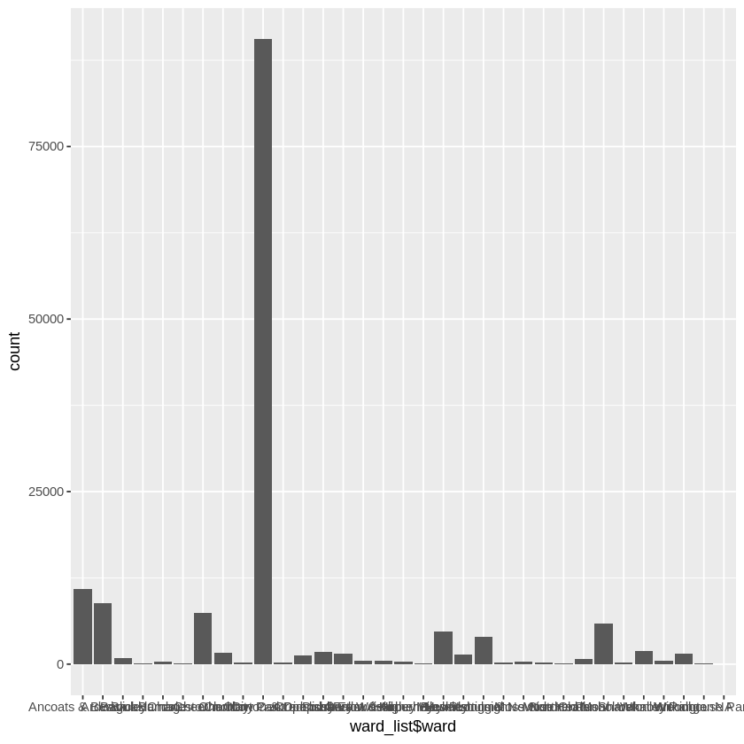

```r
ggplot(ward_list, mapping=aes(x=ward_list$ward)) +
    geom_bar()
```

Well it's a start, but this is a pretty awful chart. Luckily there are several ways we can improve it.

Let's order the wards by number of tickets:

```r
library(forcats)
ward_list$ward = fct_infreq(ward_list$ward)
```

We'll make a new data frame with the count already in a log10 scale, and with the field name capitalised. Though we won't use this df immediately, it will be useful later when we create a map.

```r
parking_wards <- count(ward_list, ward)
parking_wards$n <- log10(parking_wards$n)
colnames(parking_wards)[colnames(parking_wards)=="ward"] <- "Ward"
# or we can let ggplot do the conversion in the next cell. I'll keep this log10 df for later mapping though.
```

As part of the call to ggplot in the cell below we will also (in order):

colour the bars, request a log 10 scale and specific y-axis labels, rotate the x-axis labels, specify axis titles, and limit the scope of the y-axis.

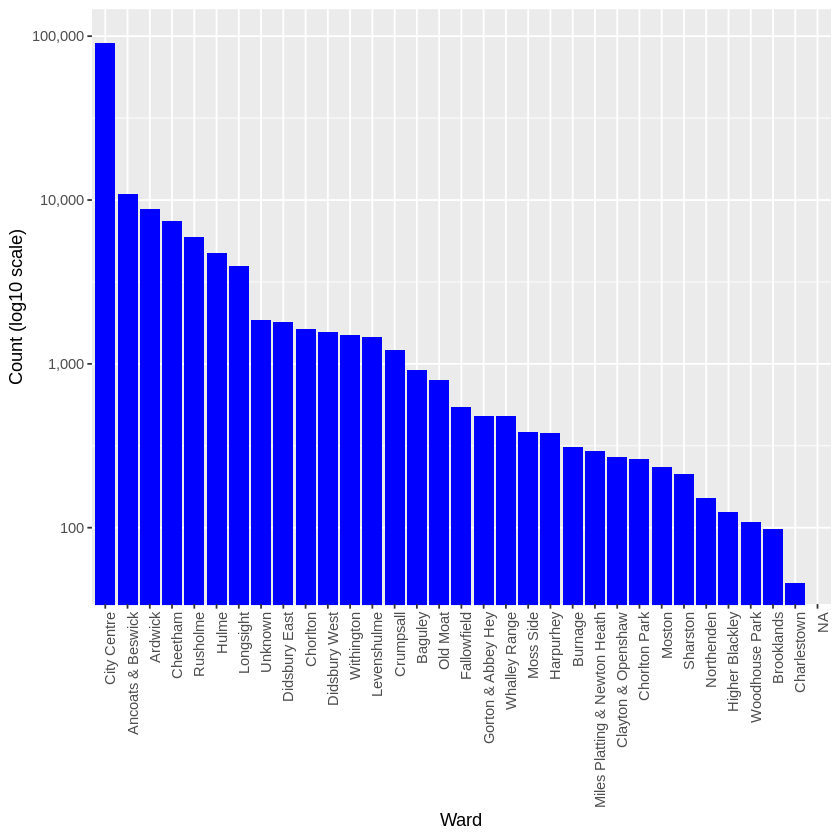

```r
library(scales)
ggplot(ward_list, mapping=aes(x=ward_list$ward)) +
    geom_bar(fill="blue") +
    scale_y_log10(breaks=c(100, 1000, 10000, 100000), labels=comma) +
    theme(axis.text.x=element_text(angle=90, hjust=1)) +
    labs(x="Ward", y="Count (log10 scale)") +
    coord_cartesian(ylim=c(50, 100000))
```

Now we have something usable. We can see that the vast majority of tickets are issued in the city centre. The next most frequent areas are also inner-city urban wards, while the suburban areas further from the centre tend to attract fewer tickets. This accords with our intuition, as both parking restrictions AND Parking Enforcement Officer patrols are likely to be more common the closer to the city centre you go. However, the sheer scale of the disparity (less obvious with a logarithmic y-axis) is surprising and might lead one to conclude that extra attention should be paid by enforcement officers to the wards further from the city centre.

Let's explore some other aspects of the data:

```r
parking_dates <- data.frame(date=as.Date(parking_test$Issued))
parking_dates2 <- count(parking_dates, date)
```

Above we counted the number of tickets issued on each date. Let's plot that next:

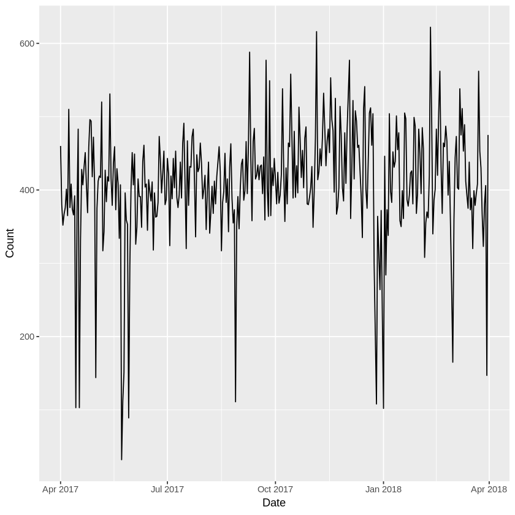

```r
ggplot(data=parking_dates2, mapping=aes(x=parking_dates2$date, y=parking_dates2$n)) +
  geom_line() +
  labs(x="Date", y="Count")
```

That looks reasonably stable. Xmas and New Year would account for the two troughs we can see around Jan 2018, though the rest of the outliers are harder to explain.

Let's try some altenative groupings, starting with Month

```r
library(lubridate)
parking_months <- data.frame(month=month(parking_test$Issued))
parking_months2 <- count(parking_months, month)
```

A basic plot:

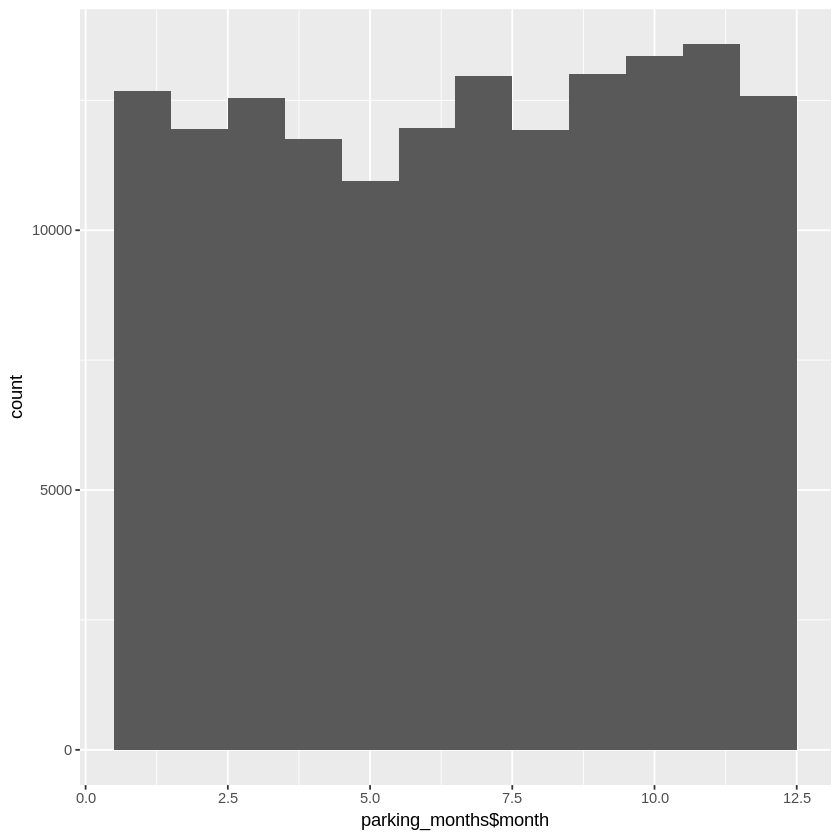

```r
ggplot(parking_months, mapping=aes(x=parking_months$month)) +
  geom_histogram(bins=12)
```

A good start; we can see that the data is behaving as expected. Of course we can still improve the plot:

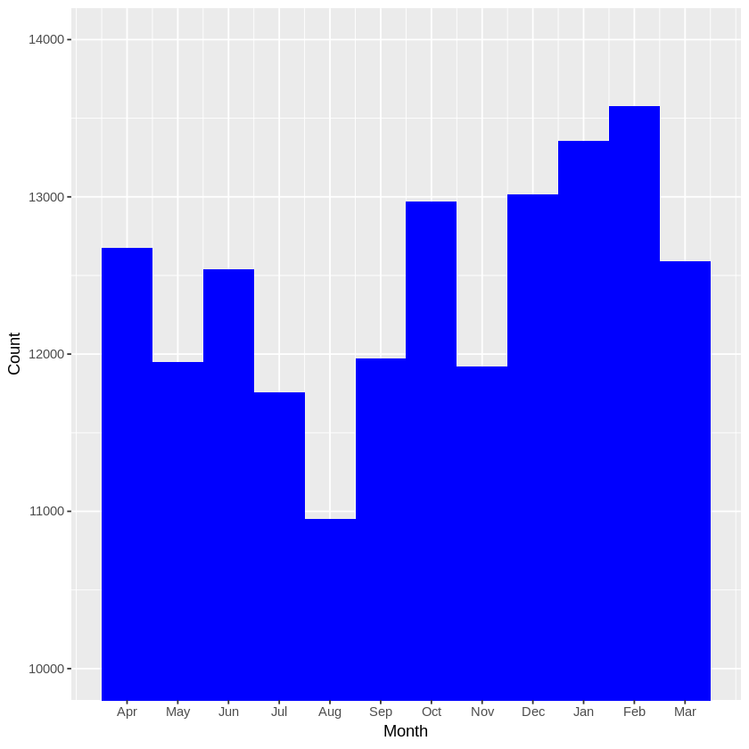

```r
ggplot(parking_months, mapping=aes(x=parking_months$month)) +
  geom_histogram(bins=12, fill="blue") +
  labs(x="Month", y="Count") +
  scale_x_continuous(breaks=c(1:12), labels=c("Apr", "May", "Jun", "Jul", "Aug", "Sep", "Oct", "Nov", "Dec", "Jan", "Feb", "Mar")) +
  coord_cartesian(ylim=c(10000,14000))
```

Note that we trimmed the y-axis to only show 10,000 to 14,000. This allows us to see more detail in the differences between months, at the expense of the data being slightly less easy to understand at first glance.

Next we'll try the same thing grouped by day of the week:

```r
parking_days <- data.frame(day=wday(parking_test$Issued))
parking_days2 <- count(parking_days, day)
```

Let's not bother with a basic version of the chart but go straight to a nice one:

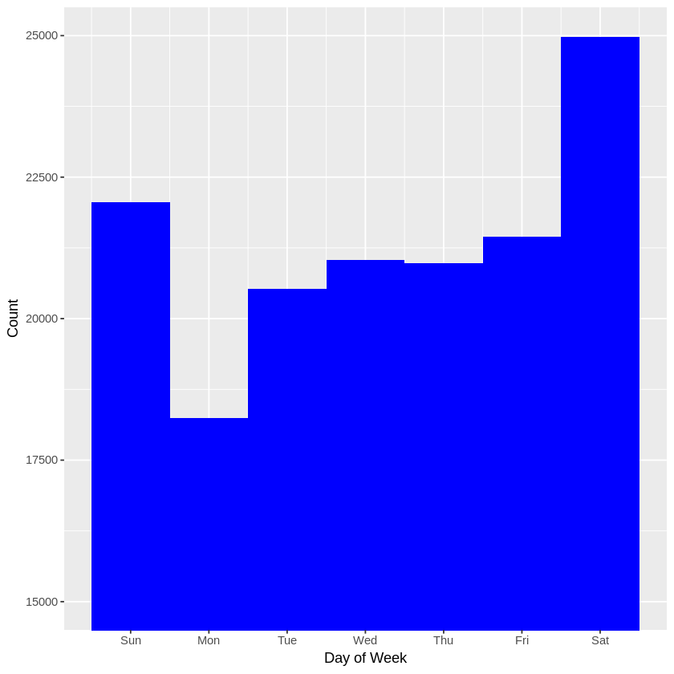

```r
ggplot(parking_days, mapping=aes(x=parking_days$day)) +
  geom_histogram(bins=7, fill="blue") +
  labs(x="Day of Week", y="Count") +
  scale_x_continuous(breaks=c(1:7), labels=c("Sun", "Mon", "Tue", "Wed", "Thu", "Fri", "Sat")) +
  coord_cartesian(ylim=c(15000,25000))
```

Once again this visualisation shows us convincing - if expected - results. The weekend sees a significant increase in tickets issued; this might be due to an increased number of people in busy streets compared to working hours. Numbers during the week are stable apart from a pronounced dip on Monday. While we could speculate as to the cause of this discrepancy, it's unlikely the data will be sufficient to confirm it.

Next, let's get mapping! First we need to read in our shapefiles

```r
library(rgdal)
shp <- readOGR("jupyter_wards.shp")
names <- readOGR("jupyter_names.shp")
```

[output not shown]

Then coerce them both to dataframes, albeit by different techniques:

```r
shp <- fortify(shp, region="Ward")
colnames(shp)[6] <- "Ward"
namesdf <- as.data.frame(names)
```

Lets join the polygon data to the parking_wards data we kept earlier:

```r
shpdf <- merge(shp, parking_wards, by="Ward", all.x=TRUE)
```

Let's check if that has worked, and rename it in the process:

```r
map_plot <- shpdf[order(shpdf$order),]
head(map_plot)
```

| Ward | long | lat | order | hole | piece | group | n |
| --- | --- | --- | --- | --- | --- | --- | --- |
| Ancoats & Beswick | 386427.8 | 398792.6 | 1 | FALSE | 1 | Ancoats & Beswick.1 | 4.034428 |
| Ancoats & Beswick | 386432.7 | 398786.8 | 2 | FALSE | 1 | Ancoats & Beswick.1 | 4.034428 |
| Ancoats & Beswick | 386441.2 | 398774.9 | 3 | FALSE | 1 | Ancoats & Beswick.1 | 4.034428 |
| Ancoats & Beswick | 386453.1 | 398761.3 | 4 | FALSE | 1 | Ancoats & Beswick.1 | 4.034428 |
| Ancoats & Beswick | 386460.2 | 398757.9 | 5 | FALSE | 1 | Ancoats & Beswick.1 | 4.034428 |
| Ancoats & Beswick | 386472.5 | 398756.5 | 6 | FALSE | 1 | Ancoats & Beswick.1 | 4.034428 |

Excellent. I think we're ready to draw a map. As previously we'll start with a basic one before we customise:

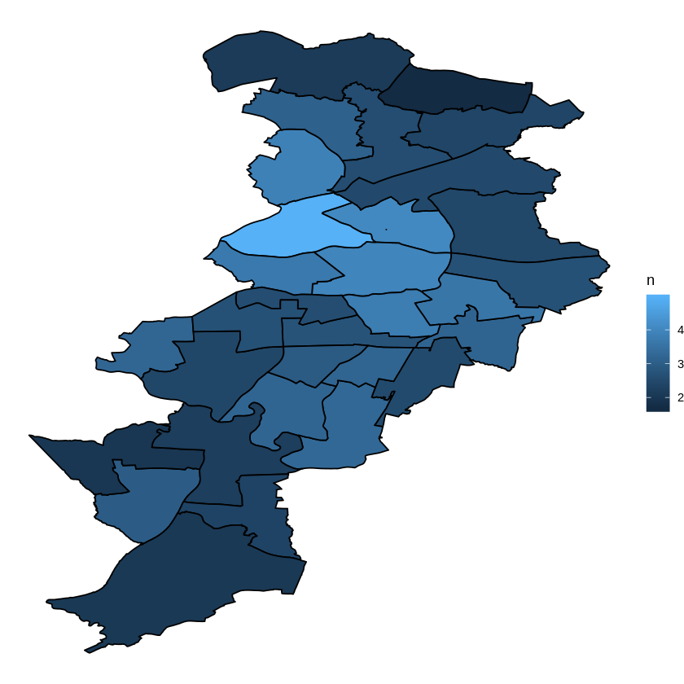

```r
ggplot() +
  geom_polygon(data=map_plot, aes(x=long, y=lat, group=group, fill=n), color="black", size=0.5) +
  theme_void()
```

That looks very promising. The only major change we need is to label the wards. For that we'll use the other shapefile we imported with points for all ward centroids. While it's possible to do this programatically in R, for a small dataset such as this with around 30 points it's probably quicker to do manually, not to mention more accurate.

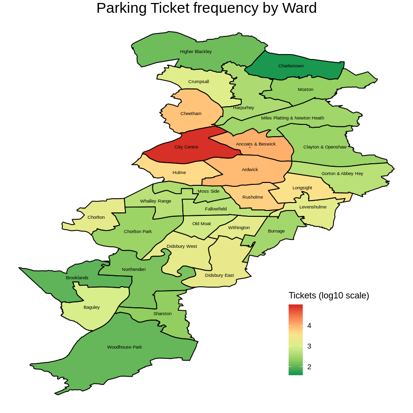

```r
library(RColorBrewer)
ggplot(data=map_plot, mapping=aes(x=long, y=lat)) +
  geom_polygon(aes(group=group, fill=n), color="black", size=0.5) +
  scale_fill_distiller(name="Tickets (log10 scale)", palette="RdYlGn") +
  theme_void() +
  geom_text(data=namesdf, aes(x=coords.x1, y=coords.x2, label=Ward), size=2) +
  theme(legend.position=c(0.8, 0.2), plot.title=element_text(size=18, hjust=0.5)) +
  ggtitle("Parking Ticket frequency by Ward")
```

This visualisation confirms my earlier statement: that number of tickets is inversely correlated to distance from the city centre. Though I was able to tell this from the bar chart, someone unfamiliar with Manchester's wards would need this map to observe the same relationship.